# Final_project

## Theme 1: Matrix Determinants

1a. Implement a function called `my_det` that calculates the determinant of a matrix recursively using expansion by cofactors (i.e., the way you learned to compute them by hand in Math 18/Math 20F. This is the first method described [here](https://en.wikipedia.org/wiki/Determinant#Definition)). The `Matrix` methods `delete_columns` and `delete_rows` may come in handy. You can assume the input is a square matrix.

```python
def minor(M,i):
    minor = M.delete_rows([0])
    minor = minor.delete_columns([i])
    return minor

def my_det(M):
    if M.nrows() == 1:
        return M[0,0]
    else:
        determinant = 0
        for x in list(range(M.nrows())):
            determinant += M[0,x]*(-1)**(x+2)*det(minor(M,x))
        return determinant
```

1b. Check that your function agrees with Sage's built-in function on a random 5 by 5 matrix of integers.

```python
m = random_matrix(ZZ,5,5)
print(m.determinant())
print(my_det(m))
```

```
348
348
```

1c. Do some timings for random $n\times n$ integer matrices for $n=5,\dots,10$ comparing your function and Sage's built-in function. Make a single plot containing both sets of results.

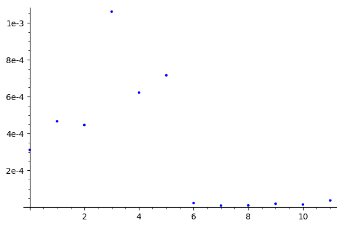

```python
import time
builtin_time = []
mydet_time = []
for n in range(5,11):
    m = random_matrix(ZZ,n,n)
    # built-in
    start_time_1 = time.time()
    m.determinant()
    builtin_time.append(time.time()-start_time_1)
    # my_det
    start_time_2 = time.time()
    my_det(m)
    mydet_time.append(time.time()-start_time_2)

list_plot(mydet_time + builtin_time)
```

1d. Explain the results of 1c in terms of the asymptotic complexity of the two methods.

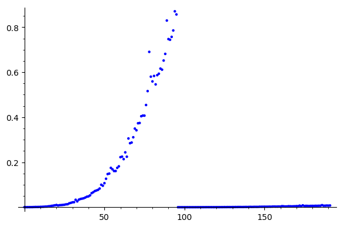

```python
builtin_time = []
mydet_time = []
for n in range(5,101):
    m = random_matrix(ZZ,n,n)
    # built-in
    start_time_1 = time.time()
    m.determinant()
    builtin_time.append(time.time()-start_time_1)
    # my_det
    start_time_2 = time.time()
    my_det(m)
    mydet_time.append(time.time()-start_time_2)

list_plot(mydet_time + builtin_time)
```

As we can see from the above graph, the asumptotic complexity of `my_det` is increasing as the size of matrices gets bigger. On the other hand, that of the built-in function is not affected as much as that `my_det`. In conclusion, the built-in function is by far efficient than `my_det`.

## Theme 2: Graphs and number theory

2a. Read the definition of a [Paley graph](https://en.wikipedia.org/wiki/Paley_graph), then write a function that, given a prime $p$ congruent to 1 modulo 4, constructs the Paley graph associated to that prime. (There also exist Paley graphs associated to prime powers, but your function need not construct those.) Note: Sage has a built-in function to do this: `graphs.PaleyGraph(p)`. Your function should *not* use this one, but it gives a good way to check your work. (Hint: You may want to reread the section on quadratic residues in the lecture on 11-07-18.)

```python
# this constructs a Paley graph
def my_paley(p):
    # raise an error message for an invalid input
    if mod(p,4) != 1:
        raise ValueError('p needs to be congruent to 1 modulo 4')
    else:
        edges = []
        v = [i for i in range(p)]
        qr = quadratic_residues(p)
        for i in range(p-1):
            for j in range(i+1,p):
                if (abs(v[i]-v[j]) in qr) and (set([v[i],v[j]]) not in edges):
                    edges.append(set([v[i],v[j]]))
        edges = list(map(tuple, edges))
        return Graph(edges)
```

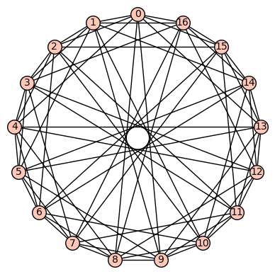

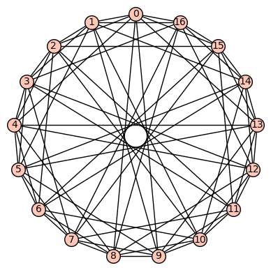

```python
# comparing with the built-in function
show(my_paley(17).plot(layout='circular'))
show(graphs.PaleyGraph(17).plot(layout='circular'))
```

2b. Using your answer to 2a for $p=13$ and the [Paley construction](https://en.wikipedia.org/wiki/Paley_construction), construct (but do not print) a $28 \times 28$ matrix which achieves the [Hadamard determinant bound](https://en.wikipedia.org/wiki/Hadamard%27s_inequality).

```python
# this produces Jacobsthal matrix which is used in Hadamard matrix
def Jacobsthal(p):
    # raise an error message for an invalid input
    if (mod(p,4) != 1) and (mod(p,4) != 3):
        raise ValueError('p needs to be congruent to 3 modulo 4')
    else:
        pos_1, neg_1, zeros = ([] for i in range(3))
        v = [i for i in range(p)]
        qr = quadratic_residues(p)
        for col in range(p):
            for row in range(p):
                if v[row]-v[col] == 0:
                    zeros.append(tuple([v[row],v[col]]))
                elif ((v[row]-v[col]) in qr) or ((p+(v[row]-v[col])) in qr):
                    pos_1.append(tuple([v[row],v[col]]))
                else:
                    neg_1.append(tuple([v[row],v[col]]))
        entries = []
        for i in range(p):
            for j in range(p):
                if (i,j) in pos_1:
                    entries.append(1)
                elif (i,j) in neg_1:
                    entries.append(-1)
                elif (i,j) in zeros:
                    entries.append(0)

        return entries
```

```python
Matrix(13,13,Jacobsthal(13))
```

```
[ 0  1 -1  1  1 -1 -1 -1 -1  1  1 -1  1]
[ 1  0  1 -1  1  1 -1 -1 -1 -1  1  1 -1]
[-1  1  0  1 -1  1  1 -1 -1 -1 -1  1  1]
[ 1 -1  1  0  1 -1  1  1 -1 -1 -1 -1  1]
[ 1  1 -1  1  0  1 -1  1  1 -1 -1 -1 -1]
[-1  1  1 -1  1  0  1 -1  1  1 -1 -1 -1]
[-1 -1  1  1 -1  1  0  1 -1  1  1 -1 -1]
[-1 -1 -1  1  1 -1  1  0  1 -1  1  1 -1]
[-1 -1 -1 -1  1  1 -1  1  0  1 -1  1  1]
[ 1 -1 -1 -1 -1  1  1 -1  1  0  1 -1  1]
[ 1  1 -1 -1 -1 -1  1  1 -1  1  0  1 -1]
[-1  1  1 -1 -1 -1 -1  1  1 -1  1  0  1]
[ 1 -1  1  1 -1 -1 -1 -1  1  1 -1  1  0]
```

```python
# this produces a Hadamard matrix
def Hadamard(p):
    # raise an error message for an invalid input
    if mod(p,4) != 1:
        raise ValueError('p needs to be congruent to 3 modulo 4')
    else:
        # construct [0, jT, j, Q]
        entries = [0]+[1 for _ in range(p)]
        j = Jacobsthal(p)
        for i in range(p):
            entries = entries + [1] + j[p*i:p*i+p]
        # Paley construction II
        final_entries = []
        for i in range(p+1):
            fr = []
            sr = []
            for j in range(p+1):
                if entries[i*p+j] == 0:
                    fr = fr + [1,-1]
                    sr = sr + [-1,-1]
                elif entries[i*p+j] == 1:
                    fr = fr + [1,1]
                    sr = sr + [1,-1]
                elif entries[i*p+j] == -1:
                    fr = fr + [-1,-1]
                    sr = sr + [-1,1]
            final_entries = final_entries + fr + sr

        return Matrix(2*(p+1),2*(p+1),final_entries)
```

```python
# define a Hadamard matrix in GF(13)
H_13 = Hadamard(13)
# the size of the matrix
print(H_13.nrows()*H_13.ncols())
```

```
784
```

2c. Check that your answer to 2b actually does achieve the Hadamard bound. According to Wikipedia, the Hadamard bound is the following

$$|det(N)|\leq\prod ||v_{i}||$$

So, we will apply this to our matrix.

```python
# this tells if a Hadamard matrix achieve the Hadamard bound
def Hadamard_bound(p):
    H = Hadamard(p)
    norm = 1
    for i in range(2*(p+1)):
        norm *= H[:,i].norm()
    print('|det(N)| = ' + str(abs(det(H))))
    print('Norm = ' + str(norm))
    if abs(det(H)) <= norm:
        return True
    else:
        return false
```

```python
Hadamard_bound(13)
```

```
|det(N)| = 131376725916385280
Norm = 1.8205911982994286e+20
```

```
True
```

## Theme 3: Distances between cities

3a. Retrieve the CSV version of the [Zip Code Database](http://zips.sourceforge.net/), upload it into your project, and import it into a DataFrame.

```python
# I'm using Python 3 (Anaconda 5) for this problem
import pandas as pd
zips = pd.read_csv("zips.csv",names=["zip_code","state_abr","latitude","longitude","city","state"])[1:]
zips.head()
```

|  | zip_code | state_abr | latitude | longitude | city | state |
| --- | --- | --- | --- | --- | --- | --- |
| 1 | 35004 | "AL" | " 33.606379" | " -86.50249" | "Moody" | "Alabama" |
| 2 | 35005 | "AL" | " 33.592585" | " -86.95969" | "Adamsville" | "Alabama" |
| 3 | 35006 | "AL" | " 33.451714" | " -87.23957" | "Adger" | "Alabama" |
| 4 | 35007 | "AL" | " 33.232422" | " -86.80871" | "Alabaster" | "Alabama" |
| 5 | 35010 | "AL" | " 32.903432" | " -85.92669" | "Alexander City" | "Alabama" |

Since the dataset values have unnecessary `" "` or extra blank spaces, we will get rid of them for easier analysis.

```python
zips["state_abr"] = zips["state_abr"].str.replace('"',"")
zips["state_abr"] = zips["state_abr"].str.replace(' ',"")
zips["latitude"] = zips["latitude"].str.replace('"',"")
zips["latitude"] = zips["latitude"].str.replace(' ',"")
zips["longitude"] = zips["longitude"].str.replace('"',"")
zips["longitude"] = zips["longitude"].str.replace(' ',"")
zips["city"] = zips["city"].str.replace('"',"")
zips["city"] = zips["city"].str.replace(' ',"")
zips["state"] = zips["state"].str.replace('"',"")
zips["state"] = zips["state"].str.replace(' ',"")
zips.head()
```

|  | zip_code | state_abr | latitude | longitude | city | state |
| --- | --- | --- | --- | --- | --- | --- |
| 1 | 35004 | AL | 33.606379 | -86.50249 | Moody | Alabama |
| 2 | 35005 | AL | 33.592585 | -86.95969 | Adamsville | Alabama |
| 3 | 35006 | AL | 33.451714 | -87.23957 | Adger | Alabama |
| 4 | 35007 | AL | 33.232422 | -86.80871 | Alabaster | Alabama |
| 5 | 35010 | AL | 32.903432 | -85.92669 | AlexanderCity | Alabama |

3b. Import the Excel file "state_capitals.xlsx" (sourced from Wikipedia, found in this directory) into a DataFrame.

```python
capitals = pd.read_excel('state_capitals.xlsx')
capitals.head(4)
```

|  | State Capitals of the United States | Unnamed: 1 | Unnamed: 2 | Unnamed: 3 | Unnamed: 4 | Unnamed: 5 | Unnamed: 6 | Unnamed: 7 | Unnamed: 8 | Unnamed: 9 | Unnamed: 10 |
| --- | --- | --- | --- | --- | --- | --- | --- | --- | --- | --- | --- |
| 0 | SNo | State | Abr. | Date of statehood | Capital | Capital since | Land area (mi²) | Most populous city? | Municipal population | Metropolitan population | Notes |
| 1 | 1 | Alabama | AL | 1819 | Montgomery | 1846 | 155.4 | No | 205764 | 374536 | Birmingham is the state's largest city |
| 2 | 2 | Alaska | AK | 1959 | Juneau | 1906 | 2716.7 | No | 31275 | NaN | Juneau is the largest capital by land area. An... |
| 3 | 3 | Arizona | AZ | 1912 | Phoenix | 1889 | 474.9 | Yes | 1445632 | 4192887 | Phoenix is the most populous U.S. state capita... |

3c. Construct a new DataFrame in which each row consists of:

- the name of a state,
- the two letter postal abbreviation of the state,
- the name of the capital city,
- a list of the zip codes associated to that city,
- the latitude and longitude associated to the first zip code in the list.

Note: For some reason, there is one capital city missing from the Zip Code Data. You should manually add this missing data to your new DataFrame. You only have to add one zip code in for this city.

```python
# extract only necessary columns
new_capitals = capitals.iloc[1:51,[1,2,4]]
# give each column a name
new_capitals = new_capitals.rename(index=str,columns={'Unnamed: 1':'state','Unnamed: 2':'state_abr','Unnamed: 4':'capital',})
# remove unnecessary blank spaces from the dataset values
new_capitals["capital"] = new_capitals["capital"].str.replace(" ","")
new_capitals["state"] = new_capitals["state"].str.replace(" ","")
new_capitals.head()
```

|  | state | state_abr | capital |
| --- | --- | --- | --- |
| 1 | Alabama | AL | Montgomery |
| 2 | Alaska | AK | Juneau |
| 3 | Arizona | AZ | Phoenix |
| 4 | Arkansas | AR | LittleRock |
| 5 | California | CA | Sacramento |

```python
# create lists of capitals and states for a for loop
capital_name = new_capitals["capital"].tolist()
state_name = new_capitals["state"].tolist()
# extract zip codes from capital cities
zip_codes = []
for i in range(50):
    zip_codes.append(zips[(zips["city"]==capital_name[i]) & (zips["state"]==state_name[i])]['zip_code'].tolist())
# add zip code data to the dataframe
new_capitals["zip"] = zip_codes
new_capitals
```

|  | state | state_abr | capital | zip |
| --- | --- | --- | --- | --- |
| 1 | Alabama | AL | Montgomery | [36104, 36105, 36106, 36107, 36108, 36109, 361... |
| 2 | Alaska | AK | Juneau | [99801, 99850] |
| 3 | Arizona | AZ | Phoenix | [85003, 85004, 85006, 85007, 85008, 85009, 850... |
| 4 | Arkansas | AR | LittleRock | [72201, 72202, 72204, 72205, 72206, 72207, 722... |
| 5 | California | CA | Sacramento | [95814, 95815, 95816, 95817, 95818, 95819, 958... |
| 6 | Colorado | CO | Denver | [80202, 80203, 80204, 80205, 80206, 80207, 802... |
| 7 | Connecticut | CT | Hartford | [06103, 06105, 06106, 06112, 06114, 06120] |
| 8 | Delaware | DE | Dover | [19901, 19904] |
| 9 | Florida | FL | Tallahassee | [32301, 32303, 32304, 32308, 32310, 32311, 323... |
| 10 | Georgia | GA | Atlanta | [30303, 30305, 30306, 30307, 30308, 30309, 303... |
| 11 | Hawaii | HI | Honolulu | [96813, 96814, 96815, 96816, 96817, 96818, 968... |
| 12 | Idaho | ID | Boise | [83702, 83703, 83704, 83705, 83706, 83709, 837... |
| 13 | Illinois | IL | Springfield | [62701] |
| 14 | Indiana | IN | Indianapolis | [46201, 46202, 46203, 46204, 46205, 46208, 462... |
| 15 | Iowa | IA | DesMoines | [50309, 50310, 50312, 50313, 50314, 50315, 503... |
| 16 | Kansas | KS | Topeka | [66603, 66604, 66605, 66606, 66607, 66608, 666... |
| 17 | Kentucky | KY | Frankfort | [] |
| 18 | Louisiana | LA | BatonRouge | [70801, 70802, 70805, 70806, 70808, 70809, 708... |
| 19 | Maine | ME | Augusta | [04330] |
| 20 | Maryland | MD | Annapolis | [21403, 21405] |
| 21 | Massachusetts | MA | Boston | [02108, 02109, 02110, 02111, 02113, 02114, 021... |
| 22 | Michigan | MI | Lansing | [48906, 48910, 48911, 48912, 48915, 48917, 48933] |
| 23 | Minnesota | MN | SaintPaul | [55101, 55102, 55103, 55104, 55105, 55106, 551... |
| 24 | Mississippi | MS | Jackson | [39201, 39202, 39203, 39204, 39206, 39209, 392... |
| 25 | Missouri | MO | JeffersonCity | [65101, 65109] |
| 26 | Montana | MT | Helena | [59601, 59602] |
| 27 | Nebraska | NE | Lincoln | [68502, 68503, 68504, 68505, 68506, 68507, 685... |
| 28 | Nevada | NV | CarsonCity | [89701, 89703, 89704, 89705] |
| 29 | NewHampshire | NH | Concord | [03301] |
| 30 | NewJersey | NJ | Trenton | [08608, 08618, 08625, 08638] |
| 31 | NewMexico | NM | SantaFe | [87505] |
| 32 | NewYork | NY | Albany | [12202, 12204, 12206, 12207, 12208, 12209, 12210] |
| 33 | NorthCarolina | NC | Raleigh | [27601, 27603, 27604, 27605, 27606, 27607, 276... |
| 34 | NorthDakota | ND | Bismarck | [58501, 58505] |
| 35 | Ohio | OH | Columbus | [43201, 43202, 43203, 43204, 43205, 43206, 432... |
| 36 | Oklahoma | OK | OklahomaCity | [73102, 73103, 73104, 73105, 73106, 73107, 731... |
| 37 | Oregon | OR | Salem | [97301, 97302, 97304, 97306] |
| 38 | Pennsylvania | PA | Harrisburg | [17101, 17102, 17104, 17110, 17112] |
| 39 | RhodeIsland | RI | Providence | [02903, 02906, 02908] |
| 40 | SouthCarolina | SC | Columbia | [29201, 29202, 29203, 29204, 29205, 29206, 292... |
| 41 | SouthDakota | SD | Pierre | [57501] |
| 42 | Tennessee | TN | Nashville | [37201, 37203, 37205, 37206, 37207, 37208, 372... |
| 43 | Texas | TX | Austin | [78701, 78702, 78703, 78704, 78705, 78717, 787... |
| 44 | Utah | UT | SaltLakeCity | [84101, 84102, 84103, 84104, 84105, 84106, 841... |
| 45 | Vermont | VT | Montpelier | [05602] |
| 46 | Virginia | VA | Richmond | [23219, 23220, 23221, 23222, 23223, 23224, 232... |
| 47 | Washington | WA | Olympia | [98501, 98502, 98512, 98513, 98516] |
| 48 | WestVirginia | WV | Charleston | [25301, 25304, 25311, 25312, 25314] |
| 49 | Wisconsin | WI | Madison | [53703, 53704, 53705, 53706, 53711, 53714, 537... |
| 50 | Wyoming | WY | Cheyenne | [82001, 82007, 82009] |

As we can see in the above dataframe, zip codes of *Frankfort*, a capital city of *Kentucky* state are missing as mentioned in the question statement. So, we need to fill the blank by searching on the Internet.  
According to [this site](https://www.zip-codes.com/city/ky-frankfort.asp), zip codes of *Frankfort* are [40601, 40602, 40603, 40604, 40618, 40619, 40620, 40621, 40622]  
Now we will add these zip codes to the dataframe.

```python
frankfort_zip = [40601, 40602, 40603, 40604, 40618, 40619, 40620, 40621, 40622]
new_capitals.at["17", 'zip'] = frankfort_zip
new_capitals
```

|  | state | state_abr | capital | zip |
| --- | --- | --- | --- | --- |
| 1 | Alabama | AL | Montgomery | [36104, 36105, 36106, 36107, 36108, 36109, 361... |
| 2 | Alaska | AK | Juneau | [99801, 99850] |
| 3 | Arizona | AZ | Phoenix | [85003, 85004, 85006, 85007, 85008, 85009, 850... |
| 4 | Arkansas | AR | LittleRock | [72201, 72202, 72204, 72205, 72206, 72207, 722... |
| 5 | California | CA | Sacramento | [95814, 95815, 95816, 95817, 95818, 95819, 958... |
| 6 | Colorado | CO | Denver | [80202, 80203, 80204, 80205, 80206, 80207, 802... |
| 7 | Connecticut | CT | Hartford | [06103, 06105, 06106, 06112, 06114, 06120] |
| 8 | Delaware | DE | Dover | [19901, 19904] |
| 9 | Florida | FL | Tallahassee | [32301, 32303, 32304, 32308, 32310, 32311, 323... |
| 10 | Georgia | GA | Atlanta | [30303, 30305, 30306, 30307, 30308, 30309, 303... |
| 11 | Hawaii | HI | Honolulu | [96813, 96814, 96815, 96816, 96817, 96818, 968... |
| 12 | Idaho | ID | Boise | [83702, 83703, 83704, 83705, 83706, 83709, 837... |
| 13 | Illinois | IL | Springfield | [62701] |
| 14 | Indiana | IN | Indianapolis | [46201, 46202, 46203, 46204, 46205, 46208, 462... |
| 15 | Iowa | IA | DesMoines | [50309, 50310, 50312, 50313, 50314, 50315, 503... |
| 16 | Kansas | KS | Topeka | [66603, 66604, 66605, 66606, 66607, 66608, 666... |
| 17 | Kentucky | KY | Frankfort | [40601, 40602, 40603, 40604, 40618, 40619, 406... |
| 18 | Louisiana | LA | BatonRouge | [70801, 70802, 70805, 70806, 70808, 70809, 708... |
| 19 | Maine | ME | Augusta | [04330] |
| 20 | Maryland | MD | Annapolis | [21403, 21405] |
| 21 | Massachusetts | MA | Boston | [02108, 02109, 02110, 02111, 02113, 02114, 021... |
| 22 | Michigan | MI | Lansing | [48906, 48910, 48911, 48912, 48915, 48917, 48933] |
| 23 | Minnesota | MN | SaintPaul | [55101, 55102, 55103, 55104, 55105, 55106, 551... |
| 24 | Mississippi | MS | Jackson | [39201, 39202, 39203, 39204, 39206, 39209, 392... |
| 25 | Missouri | MO | JeffersonCity | [65101, 65109] |
| 26 | Montana | MT | Helena | [59601, 59602] |
| 27 | Nebraska | NE | Lincoln | [68502, 68503, 68504, 68505, 68506, 68507, 685... |
| 28 | Nevada | NV | CarsonCity | [89701, 89703, 89704, 89705] |
| 29 | NewHampshire | NH | Concord | [03301] |
| 30 | NewJersey | NJ | Trenton | [08608, 08618, 08625, 08638] |
| 31 | NewMexico | NM | SantaFe | [87505] |
| 32 | NewYork | NY | Albany | [12202, 12204, 12206, 12207, 12208, 12209, 12210] |
| 33 | NorthCarolina | NC | Raleigh | [27601, 27603, 27604, 27605, 27606, 27607, 276... |
| 34 | NorthDakota | ND | Bismarck | [58501, 58505] |
| 35 | Ohio | OH | Columbus | [43201, 43202, 43203, 43204, 43205, 43206, 432... |
| 36 | Oklahoma | OK | OklahomaCity | [73102, 73103, 73104, 73105, 73106, 73107, 731... |
| 37 | Oregon | OR | Salem | [97301, 97302, 97304, 97306] |
| 38 | Pennsylvania | PA | Harrisburg | [17101, 17102, 17104, 17110, 17112] |
| 39 | RhodeIsland | RI | Providence | [02903, 02906, 02908] |
| 40 | SouthCarolina | SC | Columbia | [29201, 29202, 29203, 29204, 29205, 29206, 292... |
| 41 | SouthDakota | SD | Pierre | [57501] |
| 42 | Tennessee | TN | Nashville | [37201, 37203, 37205, 37206, 37207, 37208, 372... |
| 43 | Texas | TX | Austin | [78701, 78702, 78703, 78704, 78705, 78717, 787... |
| 44 | Utah | UT | SaltLakeCity | [84101, 84102, 84103, 84104, 84105, 84106, 841... |
| 45 | Vermont | VT | Montpelier | [05602] |
| 46 | Virginia | VA | Richmond | [23219, 23220, 23221, 23222, 23223, 23224, 232... |
| 47 | Washington | WA | Olympia | [98501, 98502, 98512, 98513, 98516] |
| 48 | WestVirginia | WV | Charleston | [25301, 25304, 25311, 25312, 25314] |
| 49 | Wisconsin | WI | Madison | [53703, 53704, 53705, 53706, 53711, 53714, 537... |
| 50 | Wyoming | WY | Cheyenne | [82001, 82007, 82009] |

```python
# Now we extract latitude and longitude data of each capital cities
lat_list = zips["latitude"].tolist()
lon_list = zips["longitude"].tolist()
capital_lat, capital_lon = [],[]
for i in range(50):
    df = zips[(zips["city"]==capital_name[i]) & (zips["state"]==state_name[i])]
    clat = ((df["latitude"].tolist()))
    clon = ((df["longitude"].tolist()))
    # since frankfort's data is missing, we add its data separately
    try:
        capital_lat.append(clat[0])
        capital_lon.append(clon[0])
    except:
        capital_lat.append(38.12)
        capital_lon.append(-84.52)
# add latitude and longitude data to the dataframe
new_capitals["lat"] = capital_lat
new_capitals["lon"] = capital_lon
new_capitals
```

|  | state | state_abr | capital | zip | lat | lon |
| --- | --- | --- | --- | --- | --- | --- |
| 1 | Alabama | AL | Montgomery | [36104, 36105, 36106, 36107, 36108, 36109, 361... | 32.377509 | -86.31068 |
| 2 | Alaska | AK | Juneau | [99801, 99850] | 58.358599 | -134.54749 |
| 3 | Arizona | AZ | Phoenix | [85003, 85004, 85006, 85007, 85008, 85009, 850... | 33.451143 | -112.07838 |
| 4 | Arkansas | AR | LittleRock | [72201, 72202, 72204, 72205, 72206, 72207, 722... | 34.745692 | -92.27987 |
| 5 | California | CA | Sacramento | [95814, 95815, 95816, 95817, 95818, 95819, 958... | 38.580255 | -121.49125 |
| 6 | Colorado | CO | Denver | [80202, 80203, 80204, 80205, 80206, 80207, 802... | 39.751586 | -104.99699 |
| 7 | Connecticut | CT | Hartford | [06103, 06105, 06106, 06112, 06114, 06120] | 41.767049 | -72.67433 |
| 8 | Delaware | DE | Dover | [19901, 19904] | 39.164260 | -75.51163 |
| 9 | Florida | FL | Tallahassee | [32301, 32303, 32304, 32308, 32310, 32311, 323... | 30.431283 | -84.26903 |
| 10 | Georgia | GA | Atlanta | [30303, 30305, 30306, 30307, 30308, 30309, 303... | 33.752856 | -84.39013 |
| 11 | Hawaii | HI | Honolulu | [96813, 96814, 96815, 96816, 96817, 96818, 968... | 21.313033 | -157.85615 |
| 12 | Idaho | ID | Boise | [83702, 83703, 83704, 83705, 83706, 83709, 837... | 43.627734 | -116.20756 |
| 13 | Illinois | IL | Springfield | [62701] | 39.800950 | -89.64999 |
| 14 | Indiana | IN | Indianapolis | [46201, 46202, 46203, 46204, 46205, 46208, 462... | 39.775125 | -86.10839 |
| 15 | Iowa | IA | DesMoines | [50309, 50310, 50312, 50313, 50314, 50315, 503... | 41.585939 | -93.62004 |
| 16 | Kansas | KS | Topeka | [66603, 66604, 66605, 66606, 66607, 66608, 666... | 39.056200 | -95.67547 |
| 17 | Kentucky | KY | Frankfort | [40601, 40602, 40603, 40604, 40618, 40619, 406... | 38.12 | -84.52 |
| 18 | Louisiana | LA | BatonRouge | [70801, 70802, 70805, 70806, 70808, 70809, 708... | 30.448840 | -91.18633 |
| 19 | Maine | ME | Augusta | [04330] | 44.344406 | -69.76345 |
| 20 | Maryland | MD | Annapolis | [21403, 21405] | 38.946462 | -76.48358 |
| 21 | Massachusetts | MA | Boston | [02108, 02109, 02110, 02111, 02113, 02114, 021... | 42.357903 | -71.06408 |
| 22 | Michigan | MI | Lansing | [48906, 48910, 48911, 48912, 48915, 48917, 48933] | 42.764167 | -84.56153 |
| 23 | Minnesota | MN | SaintPaul | [55101, 55102, 55103, 55104, 55105, 55106, 551... | 44.964852 | -93.08397 |
| 24 | Mississippi | MS | Jackson | [39201, 39202, 39203, 39204, 39206, 39209, 392... | 32.292396 | -90.18328 |
| 25 | Missouri | MO | JeffersonCity | [65101, 65109] | 38.535897 | -92.13905 |
| 26 | Montana | MT | Helena | [59601, 59602] | 46.588803 | -112.04193 |
| 27 | Nebraska | NE | Lincoln | [68502, 68503, 68504, 68505, 68506, 68507, 685... | 40.789051 | -96.69589 |
| 28 | Nevada | NV | CarsonCity | [89701, 89703, 89704, 89705] | 39.147877 | -119.74536 |
| 29 | NewHampshire | NH | Concord | [03301] | 43.213705 | -71.53774 |
| 30 | NewJersey | NJ | Trenton | [08608, 08618, 08625, 08638] | 40.219158 | -74.76481 |
| 31 | NewMexico | NM | SantaFe | [87505] | 35.616662 | -105.97926 |
| 32 | NewYork | NY | Albany | [12202, 12204, 12206, 12207, 12208, 12209, 12210] | 42.640129 | -73.76061 |
| 33 | NorthCarolina | NC | Raleigh | [27601, 27603, 27604, 27605, 27606, 27607, 276... | 35.774451 | -78.63274 |
| 34 | NorthDakota | ND | Bismarck | [58501, 58505] | 46.839620 | -100.77230 |
| 35 | Ohio | OH | Columbus | [43201, 43202, 43203, 43204, 43205, 43206, 432... | 39.990764 | -83.00117 |
| 36 | Oklahoma | OK | OklahomaCity | [73102, 73103, 73104, 73105, 73106, 73107, 731... | 35.471560 | -97.52036 |
| 37 | Oregon | OR | Salem | [97301, 97302, 97304, 97306] | 44.926644 | -122.98694 |
| 38 | Pennsylvania | PA | Harrisburg | [17101, 17102, 17104, 17110, 17112] | 40.261839 | -76.88279 |
| 39 | RhodeIsland | RI | Providence | [02903, 02906, 02908] | 41.820800 | -71.41306 |
| 40 | SouthCarolina | SC | Columbia | [29201, 29202, 29203, 29204, 29205, 29206, 292... | 33.998454 | -81.03519 |
| 41 | SouthDakota | SD | Pierre | [57501] | 44.425356 | -100.29145 |
| 42 | Tennessee | TN | Nashville | [37201, 37203, 37205, 37206, 37207, 37208, 372... | 36.164556 | -86.77738 |
| 43 | Texas | TX | Austin | [78701, 78702, 78703, 78704, 78705, 78717, 787... | 30.271270 | -97.74103 |
| 44 | Utah | UT | SaltLakeCity | [84101, 84102, 84103, 84104, 84105, 84106, 841... | 40.754746 | -111.89875 |
| 45 | Vermont | VT | Montpelier | [05602] | 44.265633 | -72.59686 |
| 46 | Virginia | VA | Richmond | [23219, 23220, 23221, 23222, 23223, 23224, 232... | 37.541046 | -77.43536 |
| 47 | Washington | WA | Olympia | [98501, 98502, 98512, 98513, 98516] | 47.014718 | -122.88190 |
| 48 | WestVirginia | WV | Charleston | [25301, 25304, 25311, 25312, 25314] | 38.350647 | -81.63028 |
| 49 | Wisconsin | WI | Madison | [53703, 53704, 53705, 53706, 53711, 53714, 537... | 43.078646 | -89.37727 |
| 50 | Wyoming | WY | Cheyenne | [82001, 82007, 82009] | 41.141281 | -104.80208 |

I retrieved the coordinate data of Frankfort, Kentucky from [here](https://en.wikipedia.org/wiki/Frankfort,_Kentucky).

```python
new_capitals.to_csv("new_capitals.csv")
```

## Theme 4: Minimum spanning trees

William Stein announces the formation of CoCalc Fiber, a new broadband network which will connect the capital cities of the 48 continental United States (excluding Alaska and Hawaii) with a series of underground cables joining certain pairs of cities. Naturally, William wants to minimize the cost of building this network; he assumes that the cost of building a network link between some pairs of cities is proportional to the distance between those two cities.

4a. Define a function that implements the [haversine formula](https://en.wikipedia.org/wiki/Haversine_formula): given two latitude-longitude pairs, compute the distance between those two points on Earth. Use kilometers instead of miles, because [the US was supposed to convert to the metric system in 1975](https://en.wikipedia.org/wiki/Metrication_in_the_United_States). Check your formula by computing the distance between Boston and San Diego, as reported by the [Great Circle Mapper](http://www.gcmap.com/) web site.

```python
def haversine(loc_1, loc_2):
    # the earth radius
    r = 6378.1
    lon_dif = (loc_2[1] - loc_1[1])*pi/180
    lat_dif = (loc_2[0] - loc_1[0])*pi/180
    d = 2*r*arcsin(sqrt(sin((lat_dif)/2)**2 + cos(loc_1[0]*pi/180)*cos(loc_2[0]*pi/180)*sin((lon_dif)/2)**2))
    return RR(d)
```

```python
san = [32.733556, -117.189666]
bos = [42.362944, -71.006388]
haversine(bos, san)
```

```
4160.40556759925
```

The [Great Circle Mapper](http://www.gcmap.com/) web site shows that the distance between the two location $4164$ km. The difference is caused by the earth's radius. I used radius information from [here](https://en.wikipedia.org/wiki/Earth_radius). However, different websites says different radius. For example, [this site](https://www.space.com/17638-how-big-is-earth.html) says the earth's radii differ depending on the locations on the earth. So we can say that our function produced approximate value which is close enought to the actual distance.

4b. Construct a complete graph on 48 vertices in which each vertex is labeled by the name of a state, and each edge is labeled by the distance between the capital cities.

```python
# we will use the dataset from 3c
import pandas as pd
data = pd.read_csv("new_capitals.csv")
data = data[["state","lat","lon"]]
data = data[(data["state"] != "Hawaii") & (data["state"] != "Alaska")].reset_index(drop=True)
lats = data['lat'].tolist()
lons = data['lon'].tolist()
states = data['state'].tolist()

coordinates = []
for i in range(48):
    coordinates.append([lats[i],lons[i]])
```

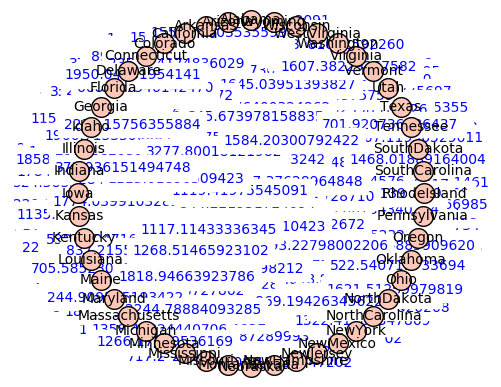

```python
vs = []
ds = []
for i in range(47):
    for j in range(i+1,48):
        vs.append(tuple([states[i], states[j]]))
        ds.append(haversine(coordinates[i], coordinates[j]))

G = Graph(vs)
for i in range(len(vs)):
    G.set_edge_label(vs[i][0], vs[i][1], ds[i])

G.plot(layout='circular', edge_labels=True)
```

4c. Construct the minimal spanning tree corresponding to the optimal CoCalc Fiber network. (Hint: You may want to reread the lecture on 10-26-18.)

```python
weighted_tree = G.min_spanning_tree()
weighted_tree
```

```
[('Alabama', 'Arizona', 2404.81968844394),
 ('Alabama', 'Arkansas', 613.110431867711),
 ('Alabama', 'California', 3242.25380381093),
 ('Alabama', 'Colorado', 1866.11139487176),
 ('Alabama', 'Connecticut', 1596.23854965114),
 ('Alabama', 'Delaware', 1232.19333012801),
 ('Alabama', 'Florida', 290.788206602129),
 ('Alabama', 'Georgia', 235.664174836029),
 ('Alabama', 'Idaho', 2884.96616265973),
 ('Alabama', 'Illinois', 879.082070499364),
 ('Alabama', 'Indiana', 823.694446037772),
 ('Alabama', 'Iowa', 1212.67478897455),
 ('Alabama', 'Kansas', 1125.39596890373),
 ('Alabama', 'Kentucky', 659.606990839463),
 ('Alabama', 'Louisiana', 510.462591950053),
 ('Alabama', 'Maine', 1957.87083012912),
 ('Alabama', 'Maryland', 1149.70316034702),
 ('Alabama', 'Massachusetts', 1742.75247649988),
 ('Alabama', 'Michigan', 1166.40696939769),
 ('Alabama', 'Minnesota', 1518.44807866100),
 ('Alabama', 'Mississippi', 364.349467271138),
 ('Alabama', 'Missouri', 865.165991868457),
 ('Alabama', 'Montana', 2698.18474565704),
 ('Alabama', 'Nebraska', 1316.65913831620),
 ('Alabama', 'Nevada', 3093.84322814101),
 ('Alabama', 'NewHampshire', 1768.07735031810),
 ('Alabama', 'NewJersey', 1352.52855721022),
 ('Alabama', 'NewMexico', 1847.37628964848),
 ('Alabama', 'NewYork', 1588.19816188476),
 ('Alabama', 'NorthCarolina', 802.242152275647),
 ('Alabama', 'NorthDakota', 2025.25549476866),
 ('Alabama', 'Ohio', 897.956121047571),
 ('Alabama', 'Oklahoma', 1090.44296322380),
 ('Alabama', 'Oregon', 3443.89415130766),
 ('Alabama', 'Pennsylvania', 1217.30860297312),
 ('Alabama', 'RhodeIsland', 1685.30641664779),
 ('Alabama', 'SouthCarolina', 523.460552300682),
 ('Alabama', 'SouthDakota', 1807.63280967112),
 ('Alabama', 'Tennessee', 423.748292320727),
 ('Alabama', 'Texas', 1111.33991862413),
 ('Alabama', 'Utah', 2459.18220431370),
 ('Alabama', 'Vermont', 1779.97152232424),
 ('Alabama', 'Virginia', 992.224297711022),
 ('Alabama', 'Washington', 3487.73823788722),
 ('Alabama', 'WestVirginia', 788.799459236029),
 ('Alabama', 'Wisconsin', 1221.20706264792),
 ('Alabama', 'Wyoming', 1910.14908992091)]
```

### Theme 5: Image compression with singular value decomposition

Run the following code to get a NumPy array corresponding to a grayscale picture of a raccoon.

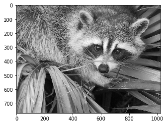

```python
import numpy as np
from scipy import misc
import matplotlib.pyplot as plt
f = misc.face(gray=True)
plt.imshow(f, cmap=plt.cm.gray)
```

Run the following code to get the [singular value decomposition](https://en.wikipedia.org/wiki/Singular_value_decomposition) of the matrix corresponding to this picture.

```python
U, Sigma, V = np.linalg.svd(f)
print("Shape of U:" + str(U.shape))
print("Shape of Sigma:" + str(Sigma.shape))
print("Shape of V:" + str(V.shape))
```

```
Shape of U:(768, 768)
Shape of Sigma:(768,)
Shape of V:(1024, 1024)
```

5a. Write a Python function that takes as input a positive integer $k$ and the arrays $U$, $\Sigma$, and $V$. It should make a $768\times k$ matrix $U_k$ from the first $k$ columns of $U$, a $k\times k$ diagonal matrix $\Sigma_k$ with the first $k$ entries of $\Sigma$ along the diagonal, and a $k\times 1024$ matrix $V_k$ from the first $k$ rows of $V$. It should then multiply these matrices to get an approximation $U_k \Sigma_k V_k$ of the original matrix and plot the corresponding grayscale picture. Note that this product will give a $768\times 1024$ matrix, so it will be the correct size.

```python
# this makes Sigma to Sigma_k
def diagonal_m(k, array):
    l = []
    for i in range(k-1):
        l.append(array[i])
        for _ in range(k):
            l.append(0)
    l.append(array[k-1])
    return Matrix(k,k,l)
```

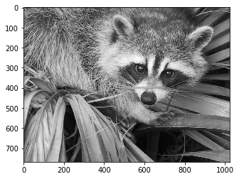

```python
def usv(k,U,Sigma,V):
    Uk, Sigmak, Vk = Matrix(U)[:,:k], diagonal_m(k,Sigma), Matrix(V)[:k,:]
    return plt.imshow(Uk*Sigmak*Vk, cmap=plt.cm.gray)

usv(768,U,Sigma,V)
```

5b. Run your function for some different values of $k$. What (approximately) is the smallest value for which the picture is recognizably a raccoon? What is the smallest value for which the picture is indistinguishable from the original?

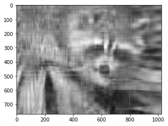

```python
usv(10,U,Sigma,V)
```

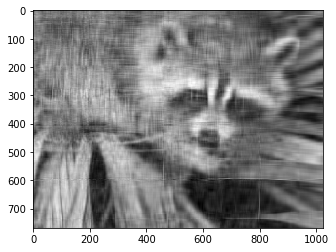

```python
usv(17,U,Sigma,V)
```

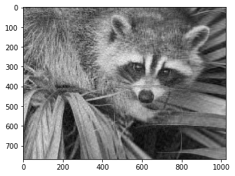

```python
usv(48,U,Sigma,V)
```

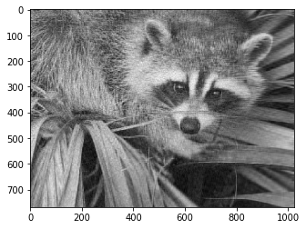

```python
usv(55,U,Sigma,V)
```

5c. As a function of $k$, what is the total combined size (number of entries) of the parts of $U$, $\Sigma$, and $V$ that are used to reconstruct the original picture? What is the compression ratio for the two values you found in 5b? (I.e., what percent of the original data was used in the reconstruction?)

Because we use the first $k$ columns of $U$(each column has 768 data), the first $k$ elements of $\Sigma$, and the first $k$ rows of $V$(each row has 1024 data), the total combined size (number of entries) of the parts of $U$, $\Sigma$, and $V$ is
$$768k+k+1024k=1793k$$

## Theme 6: Machine learning with irises

Grading criteria: correctness and relevance of code.

6a. The Wikipedia article on the [iris dataset](https://en.wikipedia.org/wiki/Iris_flower_data_set) (previously seen on homework 7) asserts:

> The use of this data set in cluster analysis however is not common, since the data set only contains two clusters with rather obvious separation.

Demonstrate this by performing a clustering computation and showing that it fails to separate all the species in the dataset. (You can change the kernel to do this.)

```python
# I'm using Python 3 (Anaconda 5) for this problem
import seaborn as sns
from sklearn.cluster import KMeans
from sklearn.decomposition import PCA
import matplotlib.pyplot as plt

iris = sns.load_dataset('iris')
# retrieve only numeric data
good_columns = iris._get_numeric_data().dropna(axis=1)
```

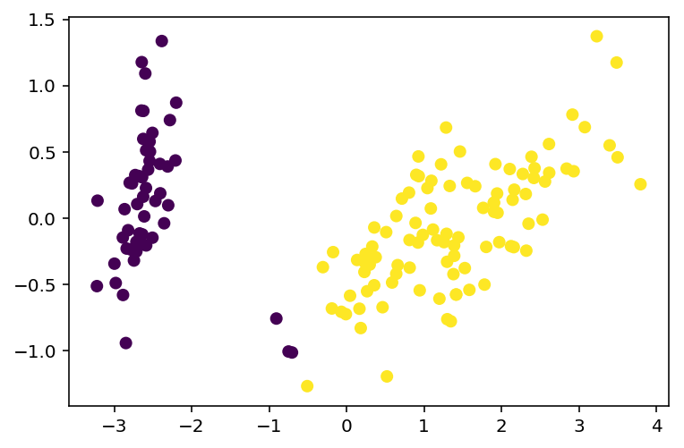

```python
# KMeans instance with two clusters
kmeans_model = KMeans(n_clusters=2, random_state=1)
kmeans_model.fit(good_columns)
labels = kmeans_model.labels_

pca_2 = PCA(2)

plot_columns = pca_2.fit_transform(good_columns)
plt.scatter(x=plot_columns[:,0], y=plot_columns[:,1], c=labels)
plt.show()
```

We can see the obvious separation between two clusters

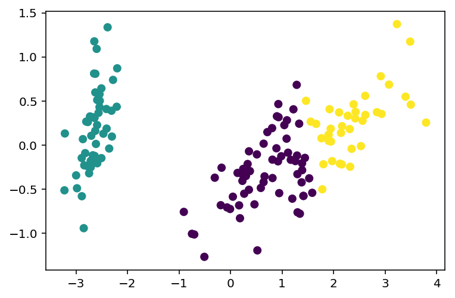

```python
# KMeans instance with three clusters
kmeans_model = KMeans(n_clusters=3, random_state=1)
kmeans_model.fit(good_columns)
labels = kmeans_model.labels_

pca_2 = PCA(2)

plot_columns = pca_2.fit_transform(good_columns)
plt.scatter(x=plot_columns[:,0], y=plot_columns[:,1], c=labels)
plt.show()
```

The purpled cluster and the yellowed one are very close to each other. We cannot say there is obvious separation between them.

6b. Use the [scikit-learn SVM classifier](http://scikit-learn.org/stable/modules/svm.html#svm-mathematical-formulation) to classify species. Use a *random* sample of 80% of the initial data for training and the other 20% for testing, and report the accuracy rate of your predictions.

```python
from sklearn import svm
# shuffle the iris dataset
iris = iris.sample(frac=1).reset_index(drop=True)
iris
```

|  | sepal_length | sepal_width | petal_length | petal_width | species |
| --- | --- | --- | --- | --- | --- |
| 0 | 4.8 | 3.0 | 1.4 | 0.1 | setosa |
| 1 | 5.4 | 3.4 | 1.7 | 0.2 | setosa |
| 2 | 6.8 | 3.2 | 5.9 | 2.3 | virginica |
| 3 | 6.7 | 3.0 | 5.0 | 1.7 | versicolor |
| 4 | 7.3 | 2.9 | 6.3 | 1.8 | virginica |
| 5 | 5.1 | 3.8 | 1.6 | 0.2 | setosa |
| 6 | 5.7 | 2.6 | 3.5 | 1.0 | versicolor |
| 7 | 4.4 | 3.0 | 1.3 | 0.2 | setosa |
| 8 | 4.3 | 3.0 | 1.1 | 0.1 | setosa |
| 9 | 5.5 | 2.6 | 4.4 | 1.2 | versicolor |
| 10 | 6.9 | 3.1 | 5.4 | 2.1 | virginica |
| 11 | 4.5 | 2.3 | 1.3 | 0.3 | setosa |
| 12 | 5.0 | 2.0 | 3.5 | 1.0 | versicolor |
| 13 | 7.9 | 3.8 | 6.4 | 2.0 | virginica |
| 14 | 5.8 | 2.6 | 4.0 | 1.2 | versicolor |
| 15 | 7.7 | 2.8 | 6.7 | 2.0 | virginica |
| 16 | 4.6 | 3.2 | 1.4 | 0.2 | setosa |
| 17 | 4.8 | 3.4 | 1.6 | 0.2 | setosa |
| 18 | 5.1 | 3.4 | 1.5 | 0.2 | setosa |
| 19 | 6.5 | 3.0 | 5.2 | 2.0 | virginica |
| 20 | 6.9 | 3.1 | 5.1 | 2.3 | virginica |
| 21 | 6.1 | 3.0 | 4.9 | 1.8 | virginica |
| 22 | 5.9 | 3.0 | 4.2 | 1.5 | versicolor |
| 23 | 5.8 | 2.8 | 5.1 | 2.4 | virginica |
| 24 | 6.3 | 2.8 | 5.1 | 1.5 | virginica |
| 25 | 4.6 | 3.4 | 1.4 | 0.3 | setosa |
| 26 | 6.5 | 3.2 | 5.1 | 2.0 | virginica |
| 27 | 5.9 | 3.2 | 4.8 | 1.8 | versicolor |
| 28 | 4.9 | 2.4 | 3.3 | 1.0 | versicolor |
| 29 | 5.0 | 3.0 | 1.6 | 0.2 | setosa |
| ... | ... | ... | ... | ... | ... |
| 120 | 5.5 | 2.5 | 4.0 | 1.3 | versicolor |
| 121 | 5.7 | 4.4 | 1.5 | 0.4 | setosa |
| 122 | 4.6 | 3.6 | 1.0 | 0.2 | setosa |
| 123 | 5.6 | 3.0 | 4.5 | 1.5 | versicolor |
| 124 | 5.8 | 2.7 | 4.1 | 1.0 | versicolor |
| 125 | 5.9 | 3.0 | 5.1 | 1.8 | virginica |
| 126 | 6.3 | 2.7 | 4.9 | 1.8 | virginica |
| 127 | 6.0 | 2.9 | 4.5 | 1.5 | versicolor |
| 128 | 6.3 | 2.5 | 4.9 | 1.5 | versicolor |
| 129 | 5.0 | 3.4 | 1.6 | 0.4 | setosa |
| 130 | 6.7 | 3.3 | 5.7 | 2.1 | virginica |
| 131 | 5.7 | 2.8 | 4.1 | 1.3 | versicolor |
| 132 | 6.2 | 3.4 | 5.4 | 2.3 | virginica |
| 133 | 6.3 | 2.5 | 5.0 | 1.9 | virginica |
| 134 | 5.2 | 3.5 | 1.5 | 0.2 | setosa |
| 135 | 5.3 | 3.7 | 1.5 | 0.2 | setosa |
| 136 | 6.3 | 2.9 | 5.6 | 1.8 | virginica |
| 137 | 5.0 | 2.3 | 3.3 | 1.0 | versicolor |
| 138 | 5.0 | 3.5 | 1.3 | 0.3 | setosa |
| 139 | 4.8 | 3.1 | 1.6 | 0.2 | setosa |
| 140 | 6.9 | 3.2 | 5.7 | 2.3 | virginica |
| 141 | 7.0 | 3.2 | 4.7 | 1.4 | versicolor |
| 142 | 5.7 | 2.5 | 5.0 | 2.0 | virginica |
| 143 | 5.8 | 2.7 | 5.1 | 1.9 | virginica |
| 144 | 5.1 | 3.5 | 1.4 | 0.3 | setosa |
| 145 | 6.2 | 2.9 | 4.3 | 1.3 | versicolor |
| 146 | 6.2 | 2.8 | 4.8 | 1.8 | virginica |
| 147 | 4.9 | 3.1 | 1.5 | 0.2 | setosa |
| 148 | 5.0 | 3.2 | 1.2 | 0.2 | setosa |
| 149 | 7.2 | 3.6 | 6.1 | 2.5 | virginica |

150 rows × 5 columns

```python
# define the target array
species = iris['species']
data = iris.iloc[:,:4]

clf = svm.SVC(gamma=0.001, C=100)
clf.fit(data[:119], species[:119])

prediction = clf.predict(data[119:])
answer = species[119:].reset_index(drop=True)
```

```python
# count the number of correct predictions
counter = 0
for i in range(len(prediction)):
    if prediction[i] == answer[i]:
        counter += 1
# calculate the accuracy
accuracy = counter/len(prediction)
accuracy
```

```
0.967741935483871
```